# Manipulação de dados com o pacote data.table

Author

Helgem de Souza

# Introdução

Muitas vezes, nas rotinas de análise de dados, é necessário trabalhar com grandes bases de dados. É fato conhecido que os pacotes padrão do R apresentam alguma dificuldade em relação à gestão de memória. Este fato se torna ainda mais saliente quando se efetuam operações com bases de dados de tamanho considerável.

Para minimizar esse aspecto técnico, algumas alternativas foram desenvolvidas para o R, em forma de pacotes para manipulação de dados. Uma das alternativas mais utilizadas é o pacote `data.table`.

[figure not shown]

Segundo a [documentação](https://rdatatable.gitlab.io/data.table/index.html), o pacote `data.table` aprimora os objetos do tipo `data.frame,` do pacote `base`. Oferece procedimentos mais rápidos de agregação, ordenamento, gestão de linhas e colunas, além de melhor gestão de memória.

A sintaxe, de fato, apresenta semelhanças com a utilização dos *data frames* padrão. Vejamos uma análise comparativa:

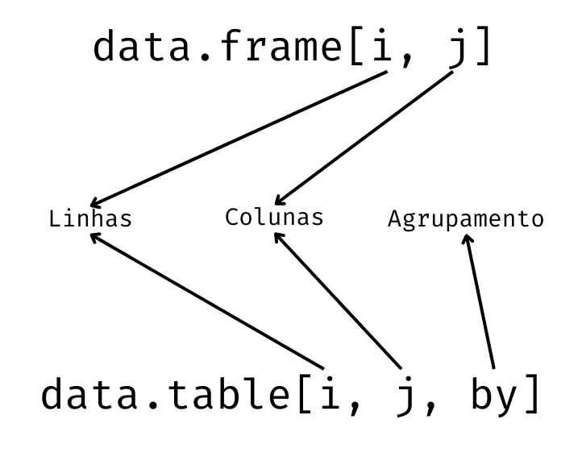

O pacote mantém a estrutura de colchetes para identificação de elementos de linhas e colunas na mesma posição de um *data frame* tradicional. Porém adiciona uma nova entrada para o agrupamento de dados. Mesmo as estruturas semelhantes ao *data frame* apresentam algumas expansões à sua funcionalidade. A rigor, os elementos de linha (**i**) funcionam de maneira semelhante à função `filter()` do pacote `dplyr`. Os elementos de colunas (**j**) por sua vez funcionam de forma que agrega as funções `select()` e `mutate()` do referido pacote, enquanto o terceiro parâmetro, `by` funciona de maneira similar à função `group_by`.

Além das funções de manipulação, o pacote `data.table` oferece uma leitura de grandes bases de dados com desempenho bastante superior às nativas. Nesta seção, trabalharemos com dados de avaliações de livros, disponível no [Kaggle](https://www.kaggle.com/datasets/saurabhbagchi/books-dataset). Apesar se não ser uma base de dados de grande dimensionalidade, contando com aproximadamente 1 milhão de linhas e 7 colunas, vamos verificar a diferença no tempo de carregamento entre os pacotes `base`, com sua função `read.csv()` e o pacote `data.table`, com sua função `fread()`. Para efetuar a comparação, utilizaremos a função `microbenchmark()`, do pacote homônimo.

```r
#Instalação e carregamento do pacote
pacman::p_load(data.table)

#Comparação dos tempos de leitura
microbenchmark::microbenchmark(

  books_base = read.csv2("datasets/a8_data_table/rating_books.csv", h = T, quote = ""),
  books_dt = fread("datasets/a8_data_table/rating_books.csv"),
  times = 10

)
```

```
Unit: milliseconds
       expr       min        lq      mean   median        uq       max neval
 books_base 1616.4606 1740.3248 2119.4612 2025.657 2125.3534 3118.3314    10
   books_dt  374.0045  653.2291  700.2649  712.627  820.2142  840.4599    10
```

```r
#Leitura dos dados
books_base <- read.csv2("datasets/a8_data_table/rating_books.csv", h = T, quote = "")
books_dt  <- fread("datasets/a8_data_table/rating_books.csv")

#Removendo a base de dados lida pela função read.csv2
rm(books_base)

#Limpeza dos rótulos de colunas
books_dt <- books_dt %>% clean_names()

#Visualização dos dados
books_dt %>% glimpse
```

```
Rows: 1,032,384
Columns: 7
$ user_id             <int> 2, 8, 11400, 11676, 41385, 67544, 85526, 96054, 11…
$ isbn                <chr> "0195153448", "0002005018", "0002005018", "0002005…
$ book_rating         <int> 0, 5, 0, 8, 0, 8, 0, 0, 9, 9, 0, 8, 9, 7, 6, 0, 8,…
$ book_title          <chr> "Classical Mythology", "Clara Callan", "Clara Call…
$ book_author         <chr> "Mark P. O. Morford", "Richard Bruce Wright", "Ric…
$ year_of_publication <int> 2002, 2001, 2001, 2001, 2001, 2001, 2001, 2001, 20…
$ publisher           <chr> "Oxford University Press", "HarperFlamingo Canada"…
```

Note que mesmo para um arquivo de tamanho médio, a diferença de desempenho é bastante significativa. A função `fread()` efetuou a importação do arquivo algumas vezes mais rápido que a tradicional `read.csv()`.

Objetos do tipo `data.frame`, `tibble` e similares podem ser convertidos para *data table*, com o uso da função `data.table`. Vejamos um exemplo:

```r
#Dataframe cars, disponível no pacote base
cars
```

```
   speed dist
1      4    2
2      4   10
3      7    4
4      7   22
5      8   16
6      9   10
7     10   18
8     10   26
9     10   34
10    11   17
11    11   28
12    12   14
13    12   20
14    12   24
```

[output cut: 36 more lines]

```r
#Dataframe convertido para data table
data.table(cars)
```

```
    speed  dist
    <num> <num>
 1:     4     2
 2:     4    10
 3:     7     4
 4:     7    22
 5:     8    16
 6:     9    10
 7:    10    18
 8:    10    26
 9:    10    34
10:    11    17
11:    11    28
12:    12    14
13:    12    20
```

[output cut: 38 more lines]

Assim como fizemos com o pacote `dlpyr`, separaremos as funções por linhas, colunas e agrupamento.

## Linhas

Assim como nos *data frames*, as operações com linhas nos *data tables* ocorrem na primeira entrada do objeto, dentro das chaves (`[]`). Assim como no pacote `dplyr`, podemos selecionar subconjuntos e ordenar linhas.

### Subconjuntos de linhas

Na seleção de subconjuntos de linhas, podem ser utilizados os seguintes operadores:

- `>` maior que;
- `>=` maior ou igual que;
- `<` menor que;
- `<=` menor ou igual que;
- `==` igual a;
- `!=` diferente de;
- `is.na()` é dado faltante;
- `!is.na()` não é dado faltante;
- `%in% x` pertence ao objeto `x;`
- `%between% c(x, y)` está entre `x` e `y;`
- `%like%` permite uso de expressões regulares.
- `sample(n)` Retorna uma amostra aleatória de tamanho n das linhas

Além destes operadores, também é possível sua combinação utilizando os operadores `&` (e) e `|` (ou). Vejamos alguns exemplos

```r
#Retorna os 10 primeiros livros
books_dt[1:10]
```

```
    user_id       isbn book_rating          book_title          book_author
      <int>     <char>       <int>              <char>               <char>
 1:       2 0195153448           0 Classical Mythology   Mark P. O. Morford
 2:       8 0002005018           5        Clara Callan Richard Bruce Wright
 3:   11400 0002005018           0        Clara Callan Richard Bruce Wright
 4:   11676 0002005018           8        Clara Callan Richard Bruce Wright
 5:   41385 0002005018           0        Clara Callan Richard Bruce Wright
 6:   67544 0002005018           8        Clara Callan Richard Bruce Wright
 7:   85526 0002005018           0        Clara Callan Richard Bruce Wright
 8:   96054 0002005018           0        Clara Callan Richard Bruce Wright
 9:  116866 0002005018           9        Clara Callan Richard Bruce Wright
10:  123629 0002005018           9        Clara Callan Richard Bruce Wright
    year_of_publication               publisher
                  <int>                  <char>
 1:                2002 Oxford University Press
 2:                2001   HarperFlamingo Canada
 3:                2001   HarperFlamingo Canada
 4:                2001   HarperFlamingo Canada
 5:                2001   HarperFlamingo Canada
 6:                2001   HarperFlamingo Canada
 7:                2001   HarperFlamingo Canada
 8:                2001   HarperFlamingo Canada
 9:                2001   HarperFlamingo Canada
10:                2001   HarperFlamingo Canada
```

```r
#Retorna todos os livros com avaliação menor que 5
books_dt[book_rating < 5]
```

```
        user_id       isbn book_rating
          <int>     <char>       <int>
     1:       2 0195153448           0
     2:   11400 0002005018           0
     3:   41385 0002005018           0
     4:   85526 0002005018           0
     5:   96054 0002005018           0
    ---
663910:  276077 014002803X           0
663911:  276579 0525447644           4
663912:  276680 006008667X           0
663913:  276680 0192126040           0
663914:  276680 0767409752           0
                                                                                                                            book_title
                                                                                                                                <char>
```

[output cut: 37 more lines]

```r
#Retorna todos os livros com avaliação entre 8 e 9
books_dt[book_rating == 8 | book_rating == 9]
```

```
        user_id       isbn book_rating
          <int>     <char>       <int>
     1:   11676 0002005018           8
     2:   67544 0002005018           8
     3:  116866 0002005018           9
     4:  123629 0002005018           9
     5:  200273 0002005018           8
    ---
152582:  271836 3404204433           8
152583:  271885 3462017942           8
152584:  274220 3453065123           9
152585:  274220 3525335423           8
152586:  274220 381440176X           8
                                                     book_title
                                                         <char>
```

[output cut: 24 more lines]

```r
#Retorna todos os livros com avaliação entre 0 e 5
books_dt[book_rating %between% c(0, 5)]
```

```
        user_id       isbn book_rating
          <int>     <char>       <int>
     1:       2 0195153448           0
     2:       8 0002005018           5
     3:   11400 0002005018           0
     4:   41385 0002005018           0
     5:   85526 0002005018           0
    ---
709265:  276313 0449906736           5
709266:  276579 0525447644           4
709267:  276680 006008667X           0
709268:  276680 0192126040           0
709269:  276680 0767409752           0
                                                                                                                            book_title
                                                                                                                                <char>
```

[output cut: 37 more lines]

```r
#Retorna livros das editoras Berkley Publishing Group e Oxford University Press
books_dt[publisher %in% c("Berkley Publishing Group", "Oxford University Press")]
```

```
       user_id       isbn book_rating
         <int>     <char>       <int>
    1:       2 0195153448           0
    2:       8 0425176428           0
    3:   52614 0425176428           8
    4:   56193 0425176428           0
    5:  225910 0425176428           0
   ---
31375:  259829 0425036596           0
31376:  259829 0425062511           0
31377:  259901 0425086615           0
31378:  268751 0195124995           0
31379:  276680 0192126040           0
                                                                            book_title
                                                                                <char>
```

[output cut: 24 more lines]

```r
#Retona todos os livros que contem a palavra Statistics no título
books_dt[book_title %like% "Statistics"]
```

```
    user_id       isbn book_rating
      <int>     <char>       <int>
 1:   10965 0135605415           7
 2:    5582 0062731025          10
 3:  123988 0062731025           2
 4:   17950 1858051576           5
 5:   19885 048660506X           7
 6:   20115 0201614774           8
 7:   25409 0071350055           9
 8:   27650 0256156034           0
 9:  252474 0256156034           7
10:   35079 0761985611           5
11:   37712 0534370926           0
12:  262998 0321056779           9
13:  268657 0534586171           4
```

[output cut: 309 more lines]

```r
#Amostra de tamanho 10 das linhas
books_dt[sample(10)]
```

```
    user_id       isbn book_rating          book_title          book_author
      <int>     <char>       <int>              <char>               <char>
 1:       8 0002005018           5        Clara Callan Richard Bruce Wright
 2:  116866 0002005018           9        Clara Callan Richard Bruce Wright
 3:  123629 0002005018           9        Clara Callan Richard Bruce Wright
 4:   41385 0002005018           0        Clara Callan Richard Bruce Wright
 5:   85526 0002005018           0        Clara Callan Richard Bruce Wright
 6:   11676 0002005018           8        Clara Callan Richard Bruce Wright
 7:   67544 0002005018           8        Clara Callan Richard Bruce Wright
 8:   96054 0002005018           0        Clara Callan Richard Bruce Wright
 9:       2 0195153448           0 Classical Mythology   Mark P. O. Morford
10:   11400 0002005018           0        Clara Callan Richard Bruce Wright
    year_of_publication               publisher
                  <int>                  <char>
 1:                2001   HarperFlamingo Canada
 2:                2001   HarperFlamingo Canada
 3:                2001   HarperFlamingo Canada
 4:                2001   HarperFlamingo Canada
 5:                2001   HarperFlamingo Canada
 6:                2001   HarperFlamingo Canada
 7:                2001   HarperFlamingo Canada
 8:                2001   HarperFlamingo Canada
 9:                2002 Oxford University Press
10:                2001   HarperFlamingo Canada
```

### Ordenamento de Linhas

Para realizar o ordenamento de linhas, com base em valores de colunas, também utilizamos a primeira entrada do *data table*. Basta informar as variáveis que serão utilizadas para ordenamento dentro da função `order()`. No caso de ordenação decrescente, basta preceder a variável pelo sinal negativo (`-`). As linhas serão ordenadas pela primeira variável, enquanto as demais servirão para eventuais desempates. Vejamos alguns exemplos.

```r
#Ordenar os livros por ordem alfabética
books_dt[order(book_title)]
```

```
         user_id       isbn book_rating
           <int>     <char>       <int>
      1:   18995 0590567330           0
      2:   35859 0590567330           0
      3:   55927 0590567330           0
      4:   96448 0590567330           9
      5:  269557 0310232546           8
     ---
1032380:   90839 3442725739           8
1032381:  243548 3442725739           0
1032382:  261105 3442725739           0
1032383:   25436 2842192508           8
1032384:   53628 2842192508           0
                                                                                                         book_title
                                                                                                             <char>
```

[output cut: 24 more lines]

```r
#Ordenar livros por avaliação decrescente e autor em ordem crescente
books_dt[order(-book_rating, book_author)]
```

```
         user_id       isbn book_rating
           <int>     <char>       <int>
      1:   90423 0525447105          10
      2:  173291 0525447075          10
      3:  259785 0525459243          10
      4:  216557 0393303861          10
      5:   55490 0061092975          10
     ---
1032380:      NA 3806874980          NA
1032381:      NA 0843947187          NA
1032382:      NA 0875846416          NA
1032383:      NA 0803729847          NA
1032384:      NA 287714139X          NA
                                                           book_title
                                                               <char>
```

[output cut: 24 more lines]

Outra forma de ordenar linhas é por meio da funçã `setorder(DT, a, b)`, em que `DT` é o *data table*, `a` e `b` são as colunas que serão utilizadas na ordenação. Ao utilizar esta função, o objeto será atualizado com a nova ordem, sem a necessidade de atribuir novamente o objeto.

```r
#Ordenar os livros por ordem alfabética
setorder(books_dt, book_title)
head(books_dt)
```

```
   user_id       isbn book_rating
     <int>     <char>       <int>
1:   18995 0590567330           0
2:   35859 0590567330           0
3:   55927 0590567330           0
4:   96448 0590567330           9
5:  269557 0310232546           8
6:   26544 006250746X           9
                                                                                                   book_title
                                                                                                       <char>
1:  A Light in the Storm: The Civil War Diary of Amelia Martin, Fenwick Island, Delaware, 1861 (Dear America)
2:  A Light in the Storm: The Civil War Diary of Amelia Martin, Fenwick Island, Delaware, 1861 (Dear America)
3:  A Light in the Storm: The Civil War Diary of Amelia Martin, Fenwick Island, Delaware, 1861 (Dear America)
4:  A Light in the Storm: The Civil War Diary of Amelia Martin, Fenwick Island, Delaware, 1861 (Dear America)
5:                                                       Ask Lily (Young Women of Faith: Lily Series, Book 5)
6:            Earth Prayers From around the World: 365 Prayers, Poems, and Invocations for Honoring the Earth
         book_author year_of_publication                   publisher
              <char>               <int>                      <char>
1:       Karen Hesse                1999 Hyperion Books for Children
2:       Karen Hesse                1999 Hyperion Books for Children
3:       Karen Hesse                1999 Hyperion Books for Children
4:       Karen Hesse                1999 Hyperion Books for Children
5:      Nancy N. Rue                2001                  Zonderkidz
6: Elizabeth Roberts                1991          HarperSanFrancisco
```

```r
#Ordenar livros por avaliação decrescente e autor em ordem crescente
setorder(books_dt, -book_rating, book_author)
head(books_dt)
```

```
   user_id       isbn book_rating
     <int>     <char>       <int>
1:      NA 0375761306          NA
2:      NA 0486253244          NA
3:      NA 1843170817          NA
4:      NA 0316161845          NA
5:      NA 0375415343          NA
6:      NA 0385507615          NA
                                                                           book_title
                                                                               <char>
1: Hair Rules: The Ultimate Hair-Care Guide for Women With Kinky, Curly, or Wavy Hair
2:          Cut and Assemble an Old Fashioned Train in Full Color (Models &amp; Toys)
3:                                                      Shite's Unoriginal Miscellany
4:                                                            The Keys of the Kingdom
5:                                                                  A Whistling Woman
6:                                                   Blackbird House (Hoffman, Alice)
     book_author year_of_publication            publisher
          <char>               <int>               <char>
1:     A. Dickey                2003        Villard Books
2:   A. G. Smith                1987   Dover Publications
3:     A. Parody                2003 Michael O'Mara Books
4:   A.J. Cronin                1984       Back Bay Books
5:    A.S. BYATT                2002                Knopf
6: ALICE HOFFMAN                2004            Doubleday
```

## Colunas

Assim como nos *data frames*, as operações com colunas são realizadas na segunda entrada do *data table*. Dentre as operações possíveis de forma isolada, podemos selecionar colunas e realizar operações com colunas. Tais operações podem resultar em novos *data tables* ou serem agregadas ao objeto original.

### Selecionar colunas

Existem diversas formas de selecionar colunas específicas em *data tables*. Vejamos com exemplos como cada uma delas funciona

#### Selecionar colunas e retornar como um vetor.

```r
#Selecionar os autores de livros
books_dt[, book_author] %>% head
```

```
[1] "A. Dickey"     "A. G. Smith"   "A. Parody"     "A.J. Cronin"
[5] "A.S. BYATT"    "ALICE HOFFMAN"
```

#### Selecionar uma coluna, mas retornar como um *data table.*

```r
#Selecionar os autores
books_dt[, .(book_author)]
```

```
                    book_author
                         <char>
      1:              A. Dickey
      2:            A. G. Smith
      3:              A. Parody
      4:            A.J. Cronin
      5:             A.S. BYATT
     ---
1032380: \xc3?\xc2?pict\xc3?¨te
1032381:   \xc3?\xc2?ric Holder
1032382:   \xc3?\xc2?ric Holder
1032383:   \xc3?\xc2?ric Holder
1032384:   \xc3?\xc2?ric Holder
```

Para retornar a seleção como *data table*, é necessário encapsular as colunas dentro de uma lista. Caso contrário, seriam retornados vetores. Note que, os nomes de colunas não estão dentro de uma lista tradicional, no formato `list()`, e sim dentro de uma expressão `.()`. Esta expressão é um pseudônimo para listas no pacote `data.table`. Sua operação ocorre da mesma forma. Sinta-se a vontade para utilizar a forma que preferir.

#### Selecionar duas ou mais colunas

```r
#Selecionar título e avaliação
books_dt[, .(book_title, book_rating)]
```

```
                                                                                 book_title
                                                                                     <char>
      1: Hair Rules: The Ultimate Hair-Care Guide for Women With Kinky, Curly, or Wavy Hair
      2:          Cut and Assemble an Old Fashioned Train in Full Color (Models &amp; Toys)
      3:                                                      Shite's Unoriginal Miscellany
      4:                                                            The Keys of the Kingdom
      5:                                                                  A Whistling Woman
     ---
1032380:                                   Maximes et pens\xc3?©es : \xc3?\xc2?pict\xc3?¨te
1032381:                                                               Mademoiselle Chambon
1032382:                                                               Mademoiselle Chambon
1032383:                                                               Mademoiselle Chambon
1032384:                                                               Mademoiselle Chambon
         book_rating
               <int>
      1:          NA
      2:          NA
      3:          NA
      4:          NA
      5:          NA
     ---
1032380:           0
1032381:           0
1032382:           0
1032383:           0
1032384:           0
```

Assim como na seleção de uma coluna como *data table*, basta incluir os nomes das colunas dentro de uma lista. Também é possível selecionar colunas dentre duas outras e exceto aquelas dentre duas outras, de maneira similar ao feito com o pacote `dplyr`.

```r
#Selecionar variáveis entre book_rating e ebook_author
books_dt[, book_rating:book_author]
```

```
         book_rating
               <int>
      1:          NA
      2:          NA
      3:          NA
      4:          NA
      5:          NA
     ---
1032380:           0
1032381:           0
1032382:           0
1032383:           0
1032384:           0
                                                                                 book_title
                                                                                     <char>
```

[output cut: 24 more lines]

```r
#Selecionar variáveis entre book_author e book_rating
books_dt[, book_author:book_rating]
```

```
                    book_author
                         <char>
      1:              A. Dickey
      2:            A. G. Smith
      3:              A. Parody
      4:            A.J. Cronin
      5:             A.S. BYATT
     ---
1032380: \xc3?\xc2?pict\xc3?¨te
1032381:   \xc3?\xc2?ric Holder
1032382:   \xc3?\xc2?ric Holder
1032383:   \xc3?\xc2?ric Holder
1032384:   \xc3?\xc2?ric Holder
                                                                                 book_title
                                                                                     <char>
```

[output cut: 24 more lines]

```r
#Selecionar variáveis exceto aquelas entre book_rating e ebook_author
books_dt[, -(book_rating:book_author)]
```

```
         user_id       isbn year_of_publication            publisher
           <int>     <char>               <int>               <char>
      1:      NA 0375761306                2003        Villard Books
      2:      NA 0486253244                1987   Dover Publications
      3:      NA 1843170817                2003 Michael O'Mara Books
      4:      NA 0316161845                1984       Back Bay Books
      5:      NA 0375415343                2002                Knopf
     ---
1032380:  200585 2268045757                2003   Editions du Rocher
1032381:   17789 2290048763                1998              J'ai lu
1032382:   69808 2290048763                1998              J'ai lu
1032383:  224360 2290048763                1998              J'ai lu
1032384:  271707 2290048763                1998              J'ai lu
```

```r
books_dt[, !(book_rating:book_author)]
```

```
         user_id       isbn year_of_publication            publisher
           <int>     <char>               <int>               <char>
      1:      NA 0375761306                2003        Villard Books
      2:      NA 0486253244                1987   Dover Publications
      3:      NA 1843170817                2003 Michael O'Mara Books
      4:      NA 0316161845                1984       Back Bay Books
      5:      NA 0375415343                2002                Knopf
     ---
1032380:  200585 2268045757                2003   Editions du Rocher
1032381:   17789 2290048763                1998              J'ai lu
1032382:   69808 2290048763                1998              J'ai lu
1032383:  224360 2290048763                1998              J'ai lu
1032384:  271707 2290048763                1998              J'ai lu
```

#### Selecionar colunas por um vetor de nomes

Em algumas situações, como na construção de modelos ou de *dashboards*, é necessário selecionar as colunas dinamicamente. Uma das formas de realizar este tipo de operação é atribuir uma variável como um vetor de colunas, selecionado de alguma maneira, ao *data table.* Para realizar esta operação existem duas maneiras. A primeira é utilizar o prefixo `..` antes do objeto que armazena o nome das colunas selecionadas. A segunda forma é utilizar o argumento `with = FALSE`.

```r
#Definição das colunas que devem ser selecionadas
select_cols <- c("book_title", "book_author", "book_rating")

#Note que o resultado não é o esperado fornecendo apenas a variável
try(books_dt[, select_cols])
```

```
Error in `[.data.table`(books_dt, , select_cols) :
  j (o 2º argumento dentro de [...]) é um símbolo único, mas o nome da coluna 'select_cols' não foi encontrado. Se você pretendia selecionar colunas usando uma variável na chamada do escopo, tente DT[, ..select_cols]. O prefixo .. transmite um nível superior semelhante a um caminho do sistema de arq…
```

```r
#Vamos repassar a variável com o prefixo ..
books_dt[, ..select_cols]
```

```
                                                                                 book_title
                                                                                     <char>
      1: Hair Rules: The Ultimate Hair-Care Guide for Women With Kinky, Curly, or Wavy Hair
      2:          Cut and Assemble an Old Fashioned Train in Full Color (Models &amp; Toys)
      3:                                                      Shite's Unoriginal Miscellany
      4:                                                            The Keys of the Kingdom
      5:                                                                  A Whistling Woman
     ---
1032380:                                   Maximes et pens\xc3?©es : \xc3?\xc2?pict\xc3?¨te
1032381:                                                               Mademoiselle Chambon
1032382:                                                               Mademoiselle Chambon
1032383:                                                               Mademoiselle Chambon
1032384:                                                               Mademoiselle Chambon
                    book_author book_rating
                         <char>       <int>
      1:              A. Dickey          NA
      2:            A. G. Smith          NA
      3:              A. Parody          NA
      4:            A.J. Cronin          NA
      5:             A.S. BYATT          NA
     ---
1032380: \xc3?\xc2?pict\xc3?¨te           0
1032381:   \xc3?\xc2?ric Holder           0
1032382:   \xc3?\xc2?ric Holder           0
1032383:   \xc3?\xc2?ric Holder           0
1032384:   \xc3?\xc2?ric Holder           0
```

```r
#Agora utilizando with = F
books_dt[, select_cols, with = F]
```

```
                                                                                 book_title
                                                                                     <char>
      1: Hair Rules: The Ultimate Hair-Care Guide for Women With Kinky, Curly, or Wavy Hair
      2:          Cut and Assemble an Old Fashioned Train in Full Color (Models &amp; Toys)
      3:                                                      Shite's Unoriginal Miscellany
      4:                                                            The Keys of the Kingdom
      5:                                                                  A Whistling Woman
     ---
1032380:                                   Maximes et pens\xc3?©es : \xc3?\xc2?pict\xc3?¨te
1032381:                                                               Mademoiselle Chambon
1032382:                                                               Mademoiselle Chambon
1032383:                                                               Mademoiselle Chambon
1032384:                                                               Mademoiselle Chambon
                    book_author book_rating
                         <char>       <int>
      1:              A. Dickey          NA
      2:            A. G. Smith          NA
      3:              A. Parody          NA
      4:            A.J. Cronin          NA
      5:             A.S. BYATT          NA
     ---
1032380: \xc3?\xc2?pict\xc3?¨te           0
1032381:   \xc3?\xc2?ric Holder           0
1032382:   \xc3?\xc2?ric Holder           0
1032383:   \xc3?\xc2?ric Holder           0
1032384:   \xc3?\xc2?ric Holder           0
```

### Renomear colunas

Também podemos renomear as colunas de um *data table* de maneira simples com a utilização da função `setnames()` para fazer a tarefa. Basta informar o objeto *data table*, o nome ou vetor de nomes antigos e o novo nome ou vetor de novos nomes. É importante notar que, neste caso, diferente do pacote `dplyr`, a função `setnames()` atribui o novo nome à variável mesmo que o objeto não seja atribuído. Ou seja, a mudança é definitiva.

```r
#Alterando os rótulos da variáveis book_rating e book_author para rating e author
setnames(books_dt, c("book_rating", "book_author"), c("rating", "author"))
names(books_dt)
```

```
[1] "user_id"             "isbn"                "rating"
[4] "book_title"          "author"              "year_of_publication"
[7] "publisher"
```

```r
#Revertendo as alterações
setnames(books_dt, c("rating", "author"), c("book_rating", "book_author"))
names(books_dt)
```

```
[1] "user_id"             "isbn"                "book_rating"
[4] "book_title"          "book_author"         "year_of_publication"
[7] "publisher"
```

Também é possível renomear colunas ao selecioná-las:

```r
#Selecionando livro, autor e nota, traduzindo os rótulos
books_dt[, .(livro = book_title, autor = book_author, nota = book_rating)]
```

```
                                                                                      livro
                                                                                     <char>
      1: Hair Rules: The Ultimate Hair-Care Guide for Women With Kinky, Curly, or Wavy Hair
      2:          Cut and Assemble an Old Fashioned Train in Full Color (Models &amp; Toys)
      3:                                                      Shite's Unoriginal Miscellany
      4:                                                            The Keys of the Kingdom
      5:                                                                  A Whistling Woman
     ---
1032380:                                   Maximes et pens\xc3?©es : \xc3?\xc2?pict\xc3?¨te
1032381:                                                               Mademoiselle Chambon
1032382:                                                               Mademoiselle Chambon
1032383:                                                               Mademoiselle Chambon
1032384:                                                               Mademoiselle Chambon
                          autor  nota
                         <char> <int>
      1:              A. Dickey    NA
      2:            A. G. Smith    NA
      3:              A. Parody    NA
      4:            A.J. Cronin    NA
      5:             A.S. BYATT    NA
     ---
1032380: \xc3?\xc2?pict\xc3?¨te     0
1032381:   \xc3?\xc2?ric Holder     0
1032382:   \xc3?\xc2?ric Holder     0
1032383:   \xc3?\xc2?ric Holder     0
1032384:   \xc3?\xc2?ric Holder     0
```

### Cálculos com base em colunas

No pacote `data.table`, assim como no pacote `dplyr`, podemos efetuar operações com colunas, seja retornando resultados avulsos, seja agregando novas colunas.

#### Resultados gerais

Para retornar os resultados gerais, basta repassar a operação no índice **j**. Podemos também efetuar mais de um cálculo por vez, utilizando a lista `.()` e realizar as operações em conjunto com a definição de subconjuntos. Neste caso, basta utilizar as operações com linhas, conforme descrito anteriormente.

```r
#Calcular a avaliação média
books_dt[,mean(book_rating, na.rm = T)]
```

```
[1] 2.839022
```

```r
#Número de avaliações por classificação
books_dt[, length(book_rating == 10)]
```

```
[1] 1032384
```

```r
#Cálculo da avaliação média e mediana
books_dt[, .(avg_rating = mean(book_rating, na.rm = T), median_rating = median(book_rating, na.rm = T))]
```

```
   avg_rating median_rating
        <num>         <int>
1:   2.839022             0
```

```r
#Tabela de frequência absoluta de avaliações
books_dt[, .( freq_abs = book_rating %>% table)]
```

```
    freq_abs.. freq_abs.N
        <char>      <int>
 1:          0     647323
 2:          1       1481
 3:          2       2375
 4:          3       5118
 5:          4       7617
 6:          5      45355
 7:          6      31689
 8:          7      66404
 9:          8      91806
10:          9      60780
11:         10      71227
```

```r
#Avaliação média e mediana de livros, excluidas as notas 0
books_dt[book_rating > 0, .(avg_rating = mean(book_rating, na.rm = T), median_rating = median(book_rating, na.rm = T))]
```

```
   avg_rating median_rating
        <num>         <num>
1:    7.62671             8
```

Uma outra forma de contar elementos de um grupo é por meio da utilização do argumento `.N`. Ele é particularmente útil combinado com agrupamentos, conforme veremos na sequência. Caso informado fora de um agrupamento, ele retorna o número de casos, sem a necessidade de informar uma variável, como no exemplo anterior, em que usamos a função `length()`.

```r
#Número de avaliações de livros do autor Stephen King usando length()
books_dt[book_author == "Stephen King", length(book_author)]
```

```
[1] 10055
```

```r
#Número de avaliações de livros do autor Stephen King usando .N
books_dt[book_author == "Stephen King", .N]
```

```
[1] 10055
```

#### Criação de novas variáveis

A criação de novas variáveis no pacote `data.table` é bastante simples. Basta utilizar no índice **j** o operador `:=`. Uma vez definida a operação que irá gerar uma nova coluna, assim como ao renomear variáveis com o uso da função `setnames()`, não é necessário atribuir o objeto à operação. A inclusão da nova coluna ocorrerá diretamente. Para deletar uma coluna calculada, basta atribuir o valor NULL a uma coluna de mesmo nome.

Também é possível o cálculo de uma série de novas variáveis simultaneamente. Neste caso, devemos utilizar o operador `:=` como função, com a seguinte grafia: **`` `:=` ``**. Os exemplos ilustrativos a seguir tornarão mais claros seu uso.

```r
#Criação da variável século de publicação
books_dt[, century_of_publication := ifelse(year_of_publication < 2000, 20, 21)]
glimpse(books_dt)
```

```
Rows: 1,032,384
Columns: 8
$ user_id                <int> NA, NA, NA, NA, NA, NA, NA, NA, NA, NA, NA, NA,…
$ isbn                   <chr> "0375761306", "0486253244", "1843170817", "0316…
$ book_rating            <int> NA, NA, NA, NA, NA, NA, NA, NA, NA, NA, NA, NA,…
$ book_title             <chr> "Hair Rules: The Ultimate Hair-Care Guide for W…
$ book_author            <chr> "A. Dickey", "A. G. Smith", "A. Parody", "A.J. …
$ year_of_publication    <int> 2003, 1987, 2003, 1984, 2002, 2004, 2004, 2004,…
$ publisher              <chr> "Villard Books", "Dover Publications", "Michael…
$ century_of_publication <dbl> 21, 20, 21, 20, 21, 21, 21, 21, 20, 20, 21, 20,…
```

```r
#Criação das variáveis Livro de Estatística e Avaliação Positiva
books_dt[, `:=`(statistics_book = str_detect(book_title, "Statistics"),
                positive_rating = book_rating > 6)]
glimpse(books_dt)
```

```
Rows: 1,032,384
Columns: 10
$ user_id                <int> NA, NA, NA, NA, NA, NA, NA, NA, NA, NA, NA, NA,…
$ isbn                   <chr> "0375761306", "0486253244", "1843170817", "0316…
$ book_rating            <int> NA, NA, NA, NA, NA, NA, NA, NA, NA, NA, NA, NA,…
$ book_title             <chr> "Hair Rules: The Ultimate Hair-Care Guide for W…
$ book_author            <chr> "A. Dickey", "A. G. Smith", "A. Parody", "A.J. …
$ year_of_publication    <int> 2003, 1987, 2003, 1984, 2002, 2004, 2004, 2004,…
$ publisher              <chr> "Villard Books", "Dover Publications", "Michael…
$ century_of_publication <dbl> 21, 20, 21, 20, 21, 21, 21, 21, 20, 20, 21, 20,…
$ statistics_book        <lgl> FALSE, FALSE, FALSE, FALSE, FALSE, FALSE, FALSE…
$ positive_rating        <lgl> NA, NA, NA, NA, NA, NA, NA, NA, NA, NA, NA, NA,…
```

```r
#Exclusão das variáveis criadas
books_dt[, `:=`(century_of_publication = NULL,
                statistics_book = NULL,
                positive_rating = NULL)]
glimpse(books_dt)
```

```
Rows: 1,032,384
Columns: 7
$ user_id             <int> NA, NA, NA, NA, NA, NA, NA, NA, NA, NA, NA, NA, NA…
$ isbn                <chr> "0375761306", "0486253244", "1843170817", "0316161…
$ book_rating         <int> NA, NA, NA, NA, NA, NA, NA, NA, NA, NA, NA, NA, NA…
$ book_title          <chr> "Hair Rules: The Ultimate Hair-Care Guide for Wome…
$ book_author         <chr> "A. Dickey", "A. G. Smith", "A. Parody", "A.J. Cro…
$ year_of_publication <int> 2003, 1987, 2003, 1984, 2002, 2004, 2004, 2004, 19…
$ publisher           <chr> "Villard Books", "Dover Publications", "Michael O'…
```

## Grupos

Um dos principais atrativos do pacote `data.table` é o trabalho com dados agrupados. Esta é uma das características que foram adicionadas aos *data frames* tradicionais no desenvolvimento do pacote.

### Agrupamento de dados usando `by`

Para efetuar agrupamentos, utilizaremos o argumento `by`, na terceira entrada do *data table*. As operações com dados agrupados seguem o mesmo padrão apresentado anteriormente. Todos os trabalhos são realizados nas posições **i** e **j** do *data table*. É importante ressaltar que, no caso de cálculos agrupados, os mesmos devem ser relizados dentro de uma lista. Vejamos alguns exemplos ilustrativos.

```r
#Avaliação média de todos os livros
books_dt[, .(avg_rating = mean(book_rating, na.rm = T)),
         by = book_title]
```

```
                                                                                             book_title
                                                                                                 <char>
     1:              Hair Rules: The Ultimate Hair-Care Guide for Women With Kinky, Curly, or Wavy Hair
     2:                       Cut and Assemble an Old Fashioned Train in Full Color (Models &amp; Toys)
     3:                                                                   Shite's Unoriginal Miscellany
     4:                                                                         The Keys of the Kingdom
     5:                                                                               A Whistling Woman
    ---
242146:                                                    The Heart's Calling (Heartssong, Volume 116)
242147: A Course In Miracles Workbook for students Manual for Teachers (Vol I II III) (volume I II III)
242148:                                                      Dying: Facing the Facts Instruction Manual
242149:                                                  Study Guide To Accompany Cultural Anthropology
242150:                       Geschichten aus dem Wiener Wald (Gesammelte Werke / \xc3?dön von Horváth)
        avg_rating
             <num>
     1:        NaN
     2:        NaN
     3:        NaN
     4:        NaN
     5:        NaN
    ---
242146:          0
242147:          0
242148:          0
242149:          0
242150:          0
```

```r
#Número de avaliações e avaliação média de livros publicados por ano
books_dt[, .(avg_rating = mean(book_rating, na.rm = T),
             .N),
         by = year_of_publication]
```

```
     year_of_publication avg_rating     N
                   <int>      <num> <int>
  1:                2003   3.123368 72620
  2:                1987   2.486399 18917
  3:                1984   2.560119 13831
  4:                2002   3.163789 91885
  5:                2004   3.038581 26057
 ---
112:                1917   0.000000     1
113:                2012   0.000000     1
114:                1919   0.000000     1
115:                1897   0.000000     1
116:                1914   0.000000     1
```

```r
#Avaliação média e número de avaliações dos livros relacionados ao Senhor dos Aneis
books_dt[str_detect(book_title, "The Lord of the Rings"),
         .(avg_rating = mean(book_rating, na.rm = T),
           n_ratings = .N),
           by = book_title]
```

```
                                                                                                                              book_title
                                                                                                                                  <char>
 1:        The Real Middle Earth : Exploring the Magic and Mystery of the Middle Ages, J.R.R. Tolkien, and \\""The Lord of the Rings\\""
 2:                                                          The Lord of the Rings: A Location Guidebook (Lord of the Rings (Paperback))
 3:                                                                           The Fellowship of the Ring (The Lord of the Rings, Part 1)
 4:         The Fellowship of the Ring: Being the First Part of the Lord of the Rings (The Lord of the Rings / By J.R.R. Tolkien, Pt. 1)
 5:                                                                                                 The Hobbit and The Lord of the Rings
 6:                                                                                                                The Lord of the Rings
 7:                                                                              The Lord of the Rings (Leatherette Collector's Edition)
 8:                                                                                              The Lord of the Rings (Movie Art Cover)
 9:                                                                                           The Lord of the Rings (One Volume Edition)
10:                                                                               The Return of the King (The Lord of the Rings, Part 3)
11:                                                                                       The Two Towers (The Lord of the Rings, Part 2)
12:                                                                         The Hobbit : The Enchanting Prelude to The Lord of the Rings
13:                                                                                            The Lord of the Rings (BBC Dramatization)
```

[output cut: 77 more lines]

Também é possível agrupar os dados por mais de uma variável. Para tal, basta repassar ao *data table* as variáveis de agregação dentro de uma lista `.()`. O resultado é a combinação de elementos de cada variável. Por exemplo, vamos criar novamente as variáveis século de publicação e se a a avaliação é positiva. Na sequência calcularemos a avaliação média e o número de avaliações considerando ambas as variáveis.

```r
#Criação das variáveis século de publicação e Avaliação Positiva
books_dt[, `:=`(century_of_publication =
                  ifelse(year_of_publication < 2000, 20, 21),
                positive_rating = book_rating > 6)]

#Avaliação média por século e por avaliação positiva
books_dt[is.na(book_rating) == F,
         .(avg_rating = mean(book_rating, na.rm = T),
           rating_number = .N),
         by = .(century_of_publication, positive_rating)]
```

```
   century_of_publication positive_rating avg_rating rating_number
                    <num>          <lgcl>      <num>         <int>
1:                     20            TRUE  8.4763371        184107
2:                     21            TRUE  8.4630384        106110
3:                     20           FALSE  0.6150689        504415
4:                     21           FALSE  0.6709647        236543
```

Além de colunas, podemos utilizar expressões no `by`. Podemos, por exemplo, utilizar subconjuntos para agrupamentos

```r
#Avaliação média e número de livros publicados por anos anteriores e posteriores a 1990 e livros com a palavra Statistics no título
books_dt[,
         .(avg_rating = mean(book_rating, na.rm = T),
           .N),
         by = .(before_1990 = year_of_publication >= 1990,
                statistics= str_detect(book_title, "Statistics"))]
```

```
   before_1990 statistics avg_rating      N
        <lgcl>     <lgcl>      <num>  <int>
1:        TRUE      FALSE   2.892901 838364
2:       FALSE      FALSE   2.605844 193942
3:       FALSE       TRUE   2.666667     30
4:        TRUE       TRUE   3.979167     48
```

### Agrupamento ordenado usando `keyby`

Além de agrupar os dados da maneira convencional, podemos realizar a operação considerando diretamente a classificação dos valores. Para tal, basta utilizar o argumento `keyby` no lugar do argumento `by`. Assim como em outros pacotes, a classificação ocorrerá conforme a ordem das variáveis. Para ordenar de forma crescente ou decrescente, utilizamos o sinal de `-`.

```r
#Número de avaliações e avaliação média de livros publicados por ano, ordenados por ano
books_dt[,
         .(avg_rating = mean(book_rating, na.rm = T),
           .N),
         keyby = year_of_publication]
```

```
Chave: <year_of_publication>
     year_of_publication avg_rating     N
                   <int>      <num> <int>
  1:                   0   3.132834 14031
  2:                1376   4.000000     1
  3:                1378  10.000000     1
  4:                1806   5.000000     1
  5:                1897   0.000000     1
 ---
112:                2026   4.800000     5
113:                2030   3.031250    32
114:                2037  10.000000     1
115:                2038   2.375000     8
116:                2050   4.857143     7
```

```r
#Avaliação média por século e por avaliação positiva ordenadas
books_dt[is.na(book_rating) == F,
         .(avg_rating = mean(book_rating, na.rm = T),
           rating_number = .N),
         keyby = .(century_of_publication, positive_rating)]
```

```
Chave: <century_of_publication, positive_rating>
   century_of_publication positive_rating avg_rating rating_number
                    <num>          <lgcl>      <num>         <int>
1:                     20           FALSE  0.6150689        504415
2:                     20            TRUE  8.4763371        184107
3:                     21           FALSE  0.6709647        236543
4:                     21            TRUE  8.4630384        106110
```

## Chaining (Encadeamento)

Em algumas situações, não é possível efetuar o cálculo necessáro em uma única etapa. Suponha, por exemplo, calcular uma tabela de frequências absoluas e relativas por grupo a partir de uma base de dados comum. Note que a frequência absoluta de cada grupo será calculada com base nos dados e, posteriormente ao cálculo dessa frequência agrupada, os totais seriam utilizados na relativa.

Para situações desta natureza, a pacote `data.table` oferece a possibilidade de encadear tabelas. Ou seja, uma tabela calculada será trabalhada como um novo *data table, com índices* **i**, **j** e **by** próprios. O exemplo abaixo demonstra um encadeamento simples. Note que ao calcular a avaliação média por ano para os livros da década de 80, os anos são apresentados de forma desordenada, bem como a média. Se quisermos ordenar de forma decrescente pela média e posteriormente em ordem crescente pelo ano, devemos usar o encadeamento.

```r
#Tabela de avaliação média por ano classificada em ordem crescente para livros lançados na década de 80
books_dt[year_of_publication %in% 1980:1989,
         .(avg_rating = mean(book_rating, na.rm = T)),
         by = .(year_of_publication)]
```

```
    year_of_publication avg_rating
                  <int>      <num>
 1:                1987   2.486399
 2:                1984   2.560119
 3:                1986   2.552880
 4:                1989   2.519928
 5:                1983   2.492878
 6:                1982   2.385139
 7:                1988   2.509647
 8:                1980   2.433147
 9:                1981   2.486875
10:                1985   2.436728
```

```r
books_dt[year_of_publication %in% 1980:1989,
         .(avg_rating = mean(book_rating, na.rm = T)),
         by = .(year_of_publication)][order(-avg_rating, year_of_publication)]
```

```
    year_of_publication avg_rating
                  <int>      <num>
 1:                1984   2.560119
 2:                1986   2.552880
 3:                1989   2.519928
 4:                1988   2.509647
 5:                1983   2.492878
 6:                1981   2.486875
 7:                1987   2.486399
 8:                1985   2.436728
 9:                1980   2.433147
10:                1982   2.385139
```

Note que a ordenação não era possível, pois a variável `avg_rating` não existia até ser criada pelo próprio *data table*. Outro exemplo interessante é o cálculo de frequências relativas por grupo, conforme mencionado acima. Suponha calcular as avaliações médias dos livros de George R. R. Martin e J. R. R. Tolkien, classificadas por avaliações positivas e negativas. Serão necessários 2 encadeamentos, pois a primeira tabela criará as frequências, a segunda criará os totais por avaliação positiva ou negativa e o terceiro efetuará o cálculo das frequências por subgrupo. Trabalhoso não? Mas muitas vezes tais operações são necessárias, por necessitarem de atualizaçôes dinâmicas.

```r
#Frequências absolutas e relativas por editora e época de lançamento
books_dt[book_rating >0 & book_author %in% c("George R.R. Martin", "J. R. R. Tolkien"),
         .(avg_rating = mean(book_rating, na.rm = T),
           abs_freq = .N),
         by = .(book_author, positive_rating)][
           order(book_author),
           .(book_author,
             positive_rating,
             avg_rating,
             abs_freq,
             sum = sum(abs_freq)),
           by = .(positive_rating)][,
                                    .(book_author,
                                      positive_rating,
                                      avg_rating,
                                      abs_freq,
                                      rel_freq = abs_freq/sum),
                                    by = .(positive_rating)]
```

```
   positive_rating        book_author positive_rating avg_rating abs_freq
            <lgcl>             <char>          <lgcl>      <num>    <int>
1:            TRUE George R.R. Martin            TRUE   8.860000       50
2:            TRUE   J. R. R. Tolkien            TRUE   9.272177      496
3:           FALSE George R.R. Martin           FALSE   5.500000       12
4:           FALSE   J. R. R. Tolkien           FALSE   4.870968       93
     rel_freq
        <num>
1: 0.09157509
2: 0.90842491
3: 0.11428571
4: 0.88571429
```

## Combinar *data tables*

Para finalizar, podemos efetuar a união de dois *data tables* de forma bastante simples. Para tal, basta informar o *data table* principal,posteriormente o *data table* que será reunido na posição **i**, e as variáveis de união na posição **j**, por meio do parâmetro on, que deverá receber uma lista com as variáveis de cada *data table.* Vamos utilizar o arquivo *users.csv*, disponível na mesma página do Kaggle para agregar os dados dos usuários e verificar se a idade influencia na avaliação dos livros.

```r
#Leitura do arquivo
users <- fread("datasets/a8_data_table/users.csv") %>%
  clean_names
glimpse(users)
```

```
Rows: 278,858
Columns: 3
$ user_id  <int> 1, 2, 3, 4, 5, 6, 7, 8, 9, 10, 11, 12, 13, 14, 15, 16, 17, 18…
$ location <chr> "nyc, new york, usa", "stockton, california, usa", "moscow, y…
$ age      <chr> "NULL", "18", "NULL", "17", "NULL", "61", "NULL", "NULL", "NU…
```

```r
#União dos data tables
join_books <- books_dt[users, on = .(user_id = user_id)]
glimpse(join_books)
```

```
Rows: 1,217,926
Columns: 11
$ user_id                <int> 1, 2, 3, 4, 5, 6, 7, 8, 8, 8, 8, 8, 8, 8, 8, 8,…
$ isbn                   <chr> NA, "0195153448", NA, NA, NA, NA, NA, "18813201…
$ book_rating            <int> NA, 0, NA, NA, NA, NA, NA, 7, 6, 6, 5, 5, 5, 5,…
$ book_title             <chr> NA, "Classical Mythology", NA, NA, NA, NA, NA, …
$ book_author            <chr> NA, "Mark P. O. Morford", NA, NA, NA, NA, NA, "…
$ year_of_publication    <int> NA, 2002, NA, NA, NA, NA, NA, 1994, 1998, 1999,…
$ publisher              <chr> NA, "Oxford University Press", NA, NA, NA, NA, …
$ century_of_publication <dbl> NA, 21, NA, NA, NA, NA, NA, 20, 20, 20, 21, 20,…
$ positive_rating        <lgl> NA, FALSE, NA, NA, NA, NA, NA, TRUE, FALSE, FAL…
$ location               <chr> "nyc, new york, usa", "stockton, california, us…
$ age                    <chr> "NULL", "18", "NULL", "17", "NULL", "61", "NULL…
```

```r
#Vamos agora gerar a tabela de avaliação média por idade entre 15 e 60 anos, removendo dados faltantes e avaliações zeradas
#Note que os dados de idade estão em formato char, vamos converter para numérico
avg_age <- join_books[,
                      age_num := as.numeric(age)][
                        is.na(age_num) == F & age_num %between% c(15, 60),
                        .(avg_rating = mean(book_rating, na.rm = T)), keyby =. (age_num)]

avg_age
```

```
Chave: <age_num>
    age_num avg_rating
      <num>      <num>
 1:      15   3.805371
 2:      16   4.401940
 3:      17   3.933737
 4:      18   3.265920
 5:      19   3.826377
 6:      20   3.569909
 7:      21   2.619734
 8:      22   3.038179
 9:      23   2.729421
10:      24   2.739823
11:      25   2.821481
12:      26   2.967929
```

[output cut: 35 more lines]

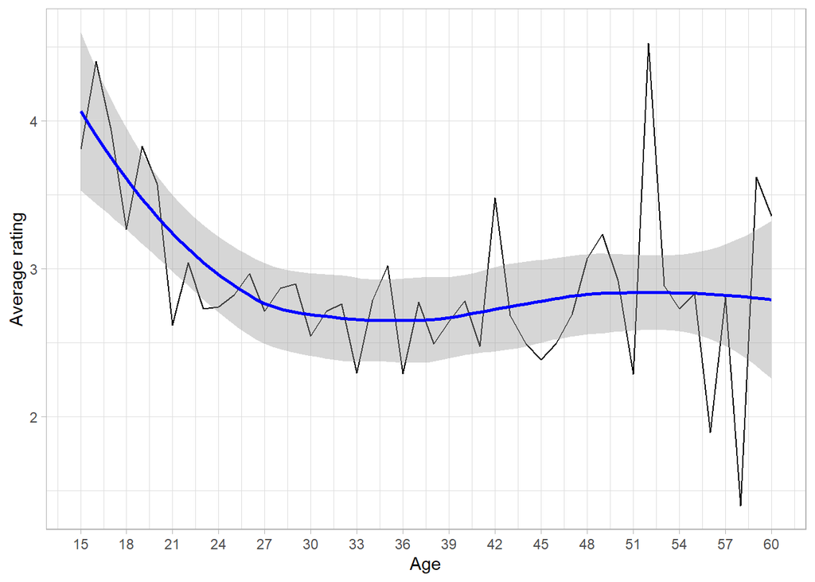

```r
avg_age %>%
  ggplot(aes(x = age_num, y = avg_rating)) +
  geom_line() +
  geom_smooth(method = 'loess', col = 'blue') +
  xlab("Age") +
  ylab("Average rating") +
  scale_x_continuous(breaks = seq(from = 15, to = 60, by = 3)) +
  theme_light()
```

Aparentemente os leitores mais jovens tendem a apresentar avaliações melhores. Ocorre uma queda até o início dos 30 anos, seguida de uma aparente estabilidade.

Existem outras funções e possibilidades interessantes no pacote `data.table`. Mais informações podem ser obtidas nos *vignettes* do pacote, bem como em sua [*cheatsheet*](https://raw.githubusercontent.com/rstudio/cheatsheets/main/translations/portuguese/datatable_pt_br.pdf), que está disponível em português.

## Exercício

Utilizando as bases de dados `flights`, `wheather` e `planes`, realize as seguintes transformações, realizadas na aula anterior com o uso do pacote `dplyr`, agora com o pacote `data.table`:

1. Crie variáveis que indiquem a situação do voo em relação ao tempo de chegada e partida, se saíram/chegaram atrasados, no horário ou adiantados.
2. No novo banco de dados, selecione os voos do mês de janeiro de 2013 e agregue as informações de temperatura e das características dos aviões.
3. Crie uma variável que deve verificar se a temperatura está acima ou abaixo de zero.
4. Verifique o desempenho relativo de cada fabricante em relação à situação do voo sobre as chegadas.
5. Verifique se a frequência de atrasos está relacionada à presença de precipitações no aeroporto de destino e à temperatura acima ou abaixo de zero.